# Module 149

#### Hemi-module gene counts:

181 probesets in hemi-module A.  
115 probesets in hemi-module B.  
Note: While the mapping of probesets to genes is usually one-to-one, some genes are targeted by multiple probesets, some probesets target multiple genes, and some probesets do not target any genes (i.e., the region of the genome they match is no longer considered genic).

#### Contrast SVE:

Signed variance explained (SVE) provides an indication of how similar a set of fold changes are to a gene module’s weight vector. An SVE value of 0.3, for example, indicates that 30% of the variance explained by the entire module set is accounted for by the module in question. Shown here are the SVE values for this module across a compendium of fold changes (contrasts). Extreme SVE values (e.g., > 0.05) indicate that those contrasts specifically induce (orange dots) or specifically repress (blue dots) this module. Examining the experimental conditions being compared in such contrasts (see tables below the figure) may provide insight into the gene module’s function.

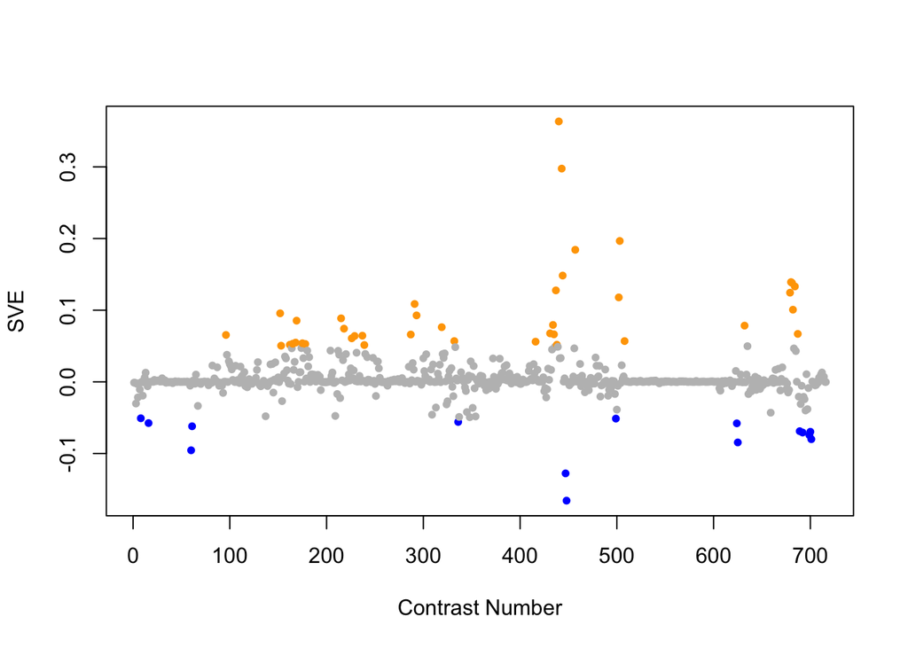

Positive SVE Contrasts:

|  | Contrast.Num | SVE | GEO.GSE | Cond.1 | Cond.2 | Mutation |
| --- | --- | --- | --- | --- | --- | --- |
| GSE27677B.s1t2.vs.s1t1 | 440 | 0.36 | GSE27677 | N2, Fast 3 h, rep 1 | N2, Fed 0 h, rep 1 |  |
| GSE27677B.s1t3.vs.s1t1 | 443 | 0.30 | GSE27677 | N2, Fast 6 h, rep 1 | N2, Fed 0 h, rep 1 |  |
| GSE22660.s1t2.vs.s0t2 | 503 | 0.20 | GSE22660 | 1ug/ml ivermectin exposure, biological rep 1 | 1ug/ml DMSO control, biological rep 1 |  |
| GSE24847.s1t3.vs.s1t1 | 457 | 0.18 | GSE24847 | young adult_4hr MWCNT exposure_rep1 | young adult_0h MWCNT exposure_rep1 |  |
| GSE27677B.s1t4.vs.s1t1 | 444 | 0.15 | GSE27677 | N2, Fast 9 h, rep 1 | N2, Fed 0 h, rep 1 |  |
| GSE12298A.s1t1.vs.s0t1 | 680 | 0.14 | GSE12298 | dichlorvos_low_dose-rep1 | dichlorvos_control-rep1 |  |
| GSE12298A.s2t1.vs.s0t1 | 681 | 0.14 | GSE12298 | dichlorvos_mid_dose-rep1 | dichlorvos_control-rep1 |  |
| GSE12298B.s2t1.vs.s0t1 | 684 | 0.13 | GSE12298 | fenamiphos_mid_dose-rep1 | fenamiphos_control-rep1 |  |
| GSE27677B.s1t5.vs.s1t1 | 437 | 0.13 | GSE27677 | N2, Fast 12 h, rep 1 | N2, Fed 0 h, rep 1 |  |
| GSE12298A.s3t1.vs.s0t1 | 679 | 0.12 | GSE12298 | dichlorvos_high_dose-rep1 | dichlorvos_control-rep1 |  |
| GSE22660.s1t1.vs.s0t1 | 502 | 0.12 | GSE22660 | 100ng/ml ivermectin exposure, biological rep 1 | 100ng/ml DMSO control, biological rep 1 |  |
| GSE41366C.s2t2.vs.s0t2 | 291 | 0.11 | GSE41366 | high_DDVP-continuous_expose-8h_harvest-rep1 | control-continuous_expose-2h_harvest-rep1 |  |
| GSE12298B.s3t1.vs.s0t1 | 682 | 0.10 | GSE12298 | fenamiphos_high_dose-rep1 | fenamiphos_control-rep1 |  |
| GSE47778.s1t1.vs.s3t1 | 152 | 0.10 | GSE47778 | N2; replicate 1 | daf-16; replicate 1 | daf-16 |
| GSE41366C.s2t3.vs.s0t3 | 293 | 0.09 | GSE41366 | high_DDVP-continuous_expose-14h_harvest-rep1 | control-continuous_expose-8h_harvest-rep1 |  |
| GSE42592A.s3t2.vs.s0t2 | 215 | 0.09 | GSE42592 | acrylamide_high_expose-4h_rep1 | acrylamide_control_expose-4h_rep1 |  |
| GSE47778.s5t3.vs.s3t3 | 169 | 0.09 | GSE47778 | xpa-1 10mJ/cm2; replicate 1 | daf-16; UV; replicate 1 | xpa-1 vs. daf-16 |
| GSE27677A.s0t2.vs.s0t1 | 434 | 0.08 | GSE27677 | N2, Fast , rep 1 | N2, Fed , rep 1 |  |
| GSE19310B.s1t2.vs.s1t1 | 632 | 0.08 | GSE19310 | N2 at 200 for 1 hour, rep1 | N2 at 200 for 15min, rep1 |  |
| GSE39012.s1t1.vs.s0t1 | 319 | 0.08 | GSE39012 | L3 stage worm AS_.03, biological replicate 1 | L3 stage worm AS_Control, biological replicate 1 |  |
| GSE42592A.s3t3.vs.s0t3 | 218 | 0.07 | GSE42592 | acrylamide_high_expose-8h_rep1 | acrylamide_control_expose-8h_rep1 |  |
| GSE27677A.s3t2.vs.s3t1 | 431 | 0.07 | GSE27677 | daf-16, Fast , rep 1 | daf-16, Fed , rep 1 |  |
| GSE12298C.s2t1.vs.s0t1 | 687 | 0.07 | GSE12298 | mefloquine_mid_dose-rep1 | mefloquine_control-rep1 |  |
| GSE27677B.s1t7.vs.s0t7 | 435 | 0.07 | GSE27677 | N2, Fast 24 h, rep 1 | N2, Fed 24 h, rep 1 |  |
| GSE41366C.s2t4.vs.s0t4 | 287 | 0.07 | GSE41366 | high_DDVP-continuous_expose-20h_harvest-rep1 | control-continuous_expose-14h_harvest-rep1 |  |
| GSE5793.s3t1.vs.s1t1 | 96 | 0.07 | GSE5793 | Celegans_PA14_4hours_RepA | Celegans_gacA_4hours_RepA |  |
| GSE42592C.s3t2.vs.s0t2 | 237 | 0.06 | GSE42592 | mercury_high_expose-4h_rep1 | mercury_control_expose-4h_rep1 |  |
| GSE42592B.s3t3.vs.s0t3 | 229 | 0.06 | GSE42592 | cadmium_high_expose-8h_rep1 | cadmium_control_expose-8h_rep1 |  |
| GSE42592B.s3t2.vs.s0t2 | 226 | 0.06 | GSE42592 | cadmium_high_expose-4h_rep1 | cadmium_control_expose-4h_rep1 |  |
| GSE38997.s2t2.vs.s1t2 | 332 | 0.06 | GSE38997 | experiment 4 EtBr-exposed samples at 24 h 4e24 | experiment 4 control samples at 24 h 4c24 |  |
| GSE21819.s1t1.vs.s0t1 | 508 | 0.06 | GSE21819 | CELEGANS_RN6390_8H_REP1 | CELEGANS_OP50_8H_REP1 |  |
| GSE29951.s0t2.vs.s0t1 | 416 | 0.06 | GSE29951 | C.elegans wild type raised in the presence of Cd, rep1 | C.elegans wild type raised in the absence of Cd, rep1 |  |
| GSE47778.s1t3.vs.s3t3 | 168 | 0.05 | GSE47778 | N2; UV; replicate 1 | daf-16; UV; replicate 1 | daf-16 |
| GSE47778.s5t3.vs.s1t3 | 175 | 0.05 | GSE47778 | xpa-1 10mJ/cm2; replicate 1 | N2; UV; replicate 1 | xpa-1 |
| GSE47778.s1t2.vs.s4t2 | 165 | 0.05 | GSE47778 | N2; starvation; replicate 1 | daf-2;daf-16; starvation; replicate 1 | daf-2;daf-16 |
| GSE47778.s2t2.vs.s2t1 | 178 | 0.05 | GSE47778 | daf-2; starvation; replicate 1 | daf-2; replicate 1 |  |
| GSE27677B.s1t6.vs.s1t1 | 438 | 0.05 | GSE27677 | N2, Fast 18 h, rep 1 | N2, Fed 0 h, rep 1 |  |
| GSE47778.s1t2.vs.s3t2 | 162 | 0.05 | GSE47778 | N2; starvation; replicate 1 | daf-16; starvation; replicate 1 | daf-16 |
| GSE42592C.s2t2.vs.s0t2 | 239 | 0.05 | GSE42592 | mercury_mid_expose-4h_rep1 | mercury_control_expose-4h_rep1 |  |
| GSE47778.s5t1.vs.s3t1 | 153 | 0.05 | GSE47778 | xpa-1 0mJ/cm2; replicate 1 | daf-16; replicate 1 | xpa-1 vs. daf-16 |

Negative SVE Contrasts:

|  | Contrast.Num | SVE | GEO.GSE | Cond.1 | Cond.2 | Mutation |
| --- | --- | --- | --- | --- | --- | --- |
| GSE27401.s1t1.vs.s2t1 | 448 | -0.17 | GSE27401 | Heat Killed E coli #1 | Heat Killed C. albicans #1 |  |
| GSE27401.s1t1.vs.s3t1 | 447 | -0.13 | GSE27401 | Heat Killed E coli #1 | C. albicans alive #1 |  |
| GSE9301.s3t1.vs.s1t1 | 60 | -0.10 | GSE9301 | 3-day-old TJ1090 worms without any stress (C1) | 3-day-old TJ1090 worms with oxidative stress (O1) |  |
| GSE19972.s2t1.vs.s0t1 | 625 | -0.08 | GSE19972 | transgenic myo-4::his-SUMO-1 JS63_1 | control wild type N2_1 |  |
| GSE11055.s1t5.vs.s2t5 | 701 | -0.08 | GSE11055 | L1 larvae 6 hr after hatching in the presence of food | L1 larvae 6 hr after hatching in the absence of food |  |
| GSE11055.s1t4.vs.s2t4 | 699 | -0.07 | GSE11055 | L1 larvae 3 hr after hatching in the presence of food | L1 larvae 3 hr after hatching in the absence of food |  |
| GSE11055.s5t7.vs.s2t7 | 692 | -0.07 | GSE11055 | L1 larvae starved for 12 hr after hatching and then fed for 3 hr | L1 larvae 15 hr after hatching in the absence of food |  |
| GSE11055.s1t4.vs.s3t4 | 700 | -0.07 | GSE11055 | L1 larvae 3 hr after hatching in the presence of food | L1 larvae 3 hr after hatching in the absence of food in the alternative starvation buffer M9 |  |
| GSE11055.s1t3.vs.s2t3 | 689 | -0.07 | GSE11055 | L1 larvae 1 hr after hatching in the presence of food | L1 larvae 1 hr after hatching in the absence of food |  |
| GSE9301.s3t1.vs.s2t1 | 61 | -0.06 | GSE9301 | 3-day-old TJ1090 worms without any stress (C1) | 3-day-old TJ1090 worms with skn-1 RNAi & oxidative stress (SO1) |  |
| GSE19972.s1t1.vs.s0t1 | 624 | -0.06 | GSE19972 | transgenic aex-3::his-SUMO-1 JS62_1 | control wild type N2_1 |  |
| GSE9682.s0t2.vs.s0t1 | 16 | -0.06 | GSE9682 | N2-controlRNAi-fed-biological rep1 | N2-controlRNAi-fasting-biological rep1 |  |
| GSE38997.s4t2.vs.s2t2 | 336 | -0.06 | GSE38997 | experiment 4 UVC-exposed samples at 24 h 4u24 | experiment 4 EtBr-exposed samples at 24 h 4e24 |  |
| GSE23013.s3t1.vs.s0t1 | 499 | -0.05 | GSE23013 | young adult_24hr BTF mix exposure_rep1 | young adult_not exposed_rep1 |  |
| GSE9897B.s5t1.vs.s0t1 | 8 | -0.05 | GSE9897 | Complex I RNAi Mutant 5 | Wildtype (control for RNAi) | D2030.4 |

$~$

#### Contrast SVE, Up-Regulated Genes Only:

Calculating SVE for up-regulated and down-regulated genes separately may be more informative in many cases than projecting the up- and down- gene sets together. This is due to the fact that the weight distribution of many modules is highly skewed, indicating that only one of the hemi-modules may be biologically meaningful (i.e., a set of genes are strongly correlated by only a few genes (or none) are strongly anti-correlated to that set.)

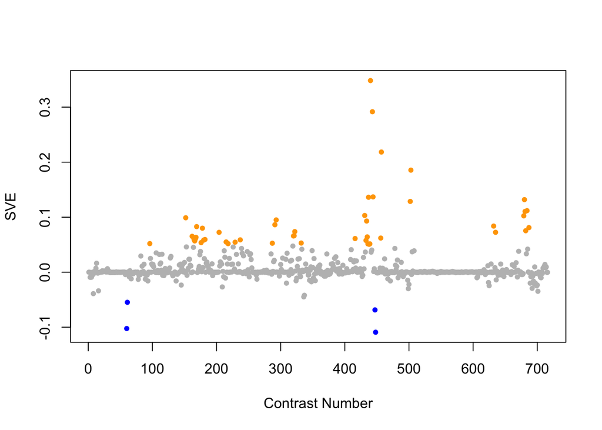

Positive SVE Contrasts:

|  | Contrast.Num | SVE | GEO.GSE | Cond.1 | Cond.2 | Mutation |
| --- | --- | --- | --- | --- | --- | --- |
| GSE27677B.s1t2.vs.s1t1 | 440 | 0.35 | GSE27677 | N2, Fast 3 h, rep 1 | N2, Fed 0 h, rep 1 |  |
| GSE27677B.s1t3.vs.s1t1 | 443 | 0.29 | GSE27677 | N2, Fast 6 h, rep 1 | N2, Fed 0 h, rep 1 |  |
| GSE24847.s1t3.vs.s1t1 | 457 | 0.22 | GSE24847 | young adult_4hr MWCNT exposure_rep1 | young adult_0h MWCNT exposure_rep1 |  |
| GSE22660.s1t2.vs.s0t2 | 503 | 0.19 | GSE22660 | 1ug/ml ivermectin exposure, biological rep 1 | 1ug/ml DMSO control, biological rep 1 |  |
| GSE27677B.s1t4.vs.s1t1 | 444 | 0.14 | GSE27677 | N2, Fast 9 h, rep 1 | N2, Fed 0 h, rep 1 |  |
| GSE27677B.s1t5.vs.s1t1 | 437 | 0.14 | GSE27677 | N2, Fast 12 h, rep 1 | N2, Fed 0 h, rep 1 |  |
| GSE12298A.s1t1.vs.s0t1 | 680 | 0.13 | GSE12298 | dichlorvos_low_dose-rep1 | dichlorvos_control-rep1 |  |
| GSE22660.s1t1.vs.s0t1 | 502 | 0.13 | GSE22660 | 100ng/ml ivermectin exposure, biological rep 1 | 100ng/ml DMSO control, biological rep 1 |  |
| GSE12298B.s2t1.vs.s0t1 | 684 | 0.11 | GSE12298 | fenamiphos_mid_dose-rep1 | fenamiphos_control-rep1 |  |
| GSE12298A.s2t1.vs.s0t1 | 681 | 0.11 | GSE12298 | dichlorvos_mid_dose-rep1 | dichlorvos_control-rep1 |  |
| GSE27677A.s3t2.vs.s3t1 | 431 | 0.10 | GSE27677 | daf-16, Fast , rep 1 | daf-16, Fed , rep 1 |  |
| GSE12298A.s3t1.vs.s0t1 | 679 | 0.10 | GSE12298 | dichlorvos_high_dose-rep1 | dichlorvos_control-rep1 |  |
| GSE47778.s1t1.vs.s3t1 | 152 | 0.10 | GSE47778 | N2; replicate 1 | daf-16; replicate 1 | daf-16 |
| GSE41366C.s2t3.vs.s0t3 | 293 | 0.10 | GSE41366 | high_DDVP-continuous_expose-14h_harvest-rep1 | control-continuous_expose-8h_harvest-rep1 |  |
| GSE27677A.s0t2.vs.s0t1 | 434 | 0.09 | GSE27677 | N2, Fast , rep 1 | N2, Fed , rep 1 |  |
| GSE41366C.s2t2.vs.s0t2 | 291 | 0.09 | GSE41366 | high_DDVP-continuous_expose-8h_harvest-rep1 | control-continuous_expose-2h_harvest-rep1 |  |
| GSE19310B.s1t2.vs.s1t1 | 632 | 0.08 | GSE19310 | N2 at 200 for 1 hour, rep1 | N2 at 200 for 15min, rep1 |  |
| GSE47778.s5t3.vs.s3t3 | 169 | 0.08 | GSE47778 | xpa-1 10mJ/cm2; replicate 1 | daf-16; UV; replicate 1 | xpa-1 vs. daf-16 |
| GSE12298C.s2t1.vs.s0t1 | 687 | 0.08 | GSE12298 | mefloquine_mid_dose-rep1 | mefloquine_control-rep1 |  |
| GSE47778.s2t2.vs.s2t1 | 178 | 0.08 | GSE47778 | daf-2; starvation; replicate 1 | daf-2; replicate 1 |  |
| GSE12298B.s3t1.vs.s0t1 | 682 | 0.08 | GSE12298 | fenamiphos_high_dose-rep1 | fenamiphos_control-rep1 |  |
| GSE38997.s4t3.vs.s1t3 | 322 | 0.07 | GSE38997 | experiment 1 UVC-exposed samples at 48 h 1u48 | experiment 1 control samples at 48 h 1c48 |  |
| GSE18157.s1t1.vs.s0t1 | 635 | 0.07 | GSE18157 | Caenorhabditis elegans in biotin deficiency 1 | Caenorhabditis elegans grown with sufficient Biotin 1 |  |
| GSE43952.s2t1.vs.s0t1 | 204 | 0.07 | GSE43952 | pcca-1(ok2282) fed Comamonas DA1877 rep1 | N2 gravid adult fed Comamonas DA1877 rep 1 | pcca-1 |
| GSE38997.s3t3.vs.s1t3 | 321 | 0.07 | GSE38997 | experiment 1 UVC- and EtBr-exposed samples at 48 h 1eu48 | experiment 1 control samples at 48 h 1c48 |  |
| GSE38997.s2t3.vs.s1t3 | 320 | 0.07 | GSE38997 | experiment 1 EtBr-exposed samples at 48 h 1e48 | experiment 1 control samples at 48 h 1c48 |  |
| GSE47778.s1t2.vs.s3t2 | 162 | 0.07 | GSE47778 | N2; starvation; replicate 1 | daf-16; starvation; replicate 1 | daf-16 |
| GSE27677B.s1t7.vs.s0t7 | 435 | 0.06 | GSE27677 | N2, Fast 24 h, rep 1 | N2, Fed 24 h, rep 1 |  |
| GSE47778.s1t3.vs.s3t3 | 168 | 0.06 | GSE47778 | N2; UV; replicate 1 | daf-16; UV; replicate 1 | daf-16 |
| GSE24847.s1t2.vs.s1t1 | 456 | 0.06 | GSE24847 | young adult_24hr MWCNT exposure_rep1 | young adult_0h MWCNT exposure_rep1 |  |
| GSE29951.s0t2.vs.s0t1 | 416 | 0.06 | GSE29951 | C.elegans wild type raised in the presence of Cd, rep1 | C.elegans wild type raised in the absence of Cd, rep1 |  |
| GSE47778.s4t3.vs.s3t3 | 167 | 0.06 | GSE47778 | daf-2;daf-16; UV; replicate 1 | daf-16; UV; replicate 1 | daf-2;daf-16 vs. daf-16 |
| GSE47778.s1t2.vs.s4t2 | 165 | 0.06 | GSE47778 | N2; starvation; replicate 1 | daf-2;daf-16; starvation; replicate 1 | daf-2;daf-16 |
| GSE47778.s1t2.vs.s1t1 | 182 | 0.06 | GSE47778 | N2; starvation; replicate 1 | N2; replicate 1 |  |
| GSE42592C.s3t2.vs.s0t2 | 237 | 0.06 | GSE42592 | mercury_high_expose-4h_rep1 | mercury_control_expose-4h_rep1 |  |
| GSE47778.s4t2.vs.s4t1 | 180 | 0.06 | GSE47778 | daf-2;daf-16; starvation; replicate 1 | daf-2;daf-16; replicate 1 |  |
| GSE27677A.s1t2.vs.s1t1 | 433 | 0.06 | GSE27677 | kgb-1, Fast , rep 1 | kgb-1, Fed , rep 1 |  |
| GSE47778.s2t3.vs.s3t3 | 166 | 0.06 | GSE47778 | daf-2; UV; replicate 1 | daf-16; UV; replicate 1 | daf-2 vs. daf-16 |
| GSE42592A.s3t2.vs.s0t2 | 215 | 0.05 | GSE42592 | acrylamide_high_expose-4h_rep1 | acrylamide_control_expose-4h_rep1 |  |
| GSE42592B.s3t3.vs.s0t3 | 229 | 0.05 | GSE42592 | cadmium_high_expose-8h_rep1 | cadmium_control_expose-8h_rep1 |  |
| GSE47778.s3t2.vs.s3t1 | 176 | 0.05 | GSE47778 | daf-16; starvation; replicate 1 | daf-16; replicate 1 |  |
| GSE38997.s2t2.vs.s1t2 | 332 | 0.05 | GSE38997 | experiment 4 EtBr-exposed samples at 24 h 4e24 | experiment 4 control samples at 24 h 4c24 |  |
| GSE41366C.s2t4.vs.s0t4 | 287 | 0.05 | GSE41366 | high_DDVP-continuous_expose-20h_harvest-rep1 | control-continuous_expose-14h_harvest-rep1 |  |
| GSE5793.s3t1.vs.s1t1 | 96 | 0.05 | GSE5793 | Celegans_PA14_4hours_RepA | Celegans_gacA_4hours_RepA |  |
| GSE42592A.s3t3.vs.s0t3 | 218 | 0.05 | GSE42592 | acrylamide_high_expose-8h_rep1 | acrylamide_control_expose-8h_rep1 |  |
| GSE27677B.s1t7.vs.s1t1 | 439 | 0.05 | GSE27677 | N2, Fast 24 h, rep 1 | N2, Fed 0 h, rep 1 |  |
| GSE27677B.s1t9.vs.s0t9 | 436 | 0.05 | GSE27677 | N2, Fast 48 h, rep 1 | N2, Fed 48 h, rep 1 |  |
| GSE27677B.s1t6.vs.s1t1 | 438 | 0.05 | GSE27677 | N2, Fast 18 h, rep 1 | N2, Fed 0 h, rep 1 |  |

Negative SVE Contrasts:

|  | Contrast.Num | SVE | GEO.GSE | Cond.1 | Cond.2 | Mutation |
| --- | --- | --- | --- | --- | --- | --- |
| GSE27401.s1t1.vs.s2t1 | 448 | -0.11 | GSE27401 | Heat Killed E coli #1 | Heat Killed C. albicans #1 |  |
| GSE9301.s3t1.vs.s1t1 | 60 | -0.10 | GSE9301 | 3-day-old TJ1090 worms without any stress (C1) | 3-day-old TJ1090 worms with oxidative stress (O1) |  |
| GSE27401.s1t1.vs.s3t1 | 447 | -0.07 | GSE27401 | Heat Killed E coli #1 | C. albicans alive #1 |  |
| GSE9301.s3t1.vs.s2t1 | 61 | -0.05 | GSE9301 | 3-day-old TJ1090 worms without any stress (C1) | 3-day-old TJ1090 worms with skn-1 RNAi & oxidative stress (SO1) |  |
| GSE38997.s4t2.vs.s2t2 | 336 | -0.04 | GSE38997 | experiment 4 UVC-exposed samples at 24 h 4u24 | experiment 4 EtBr-exposed samples at 24 h 4e24 |  |

$~$

#### Contrast SVE, Down-Regulated Genes Only:

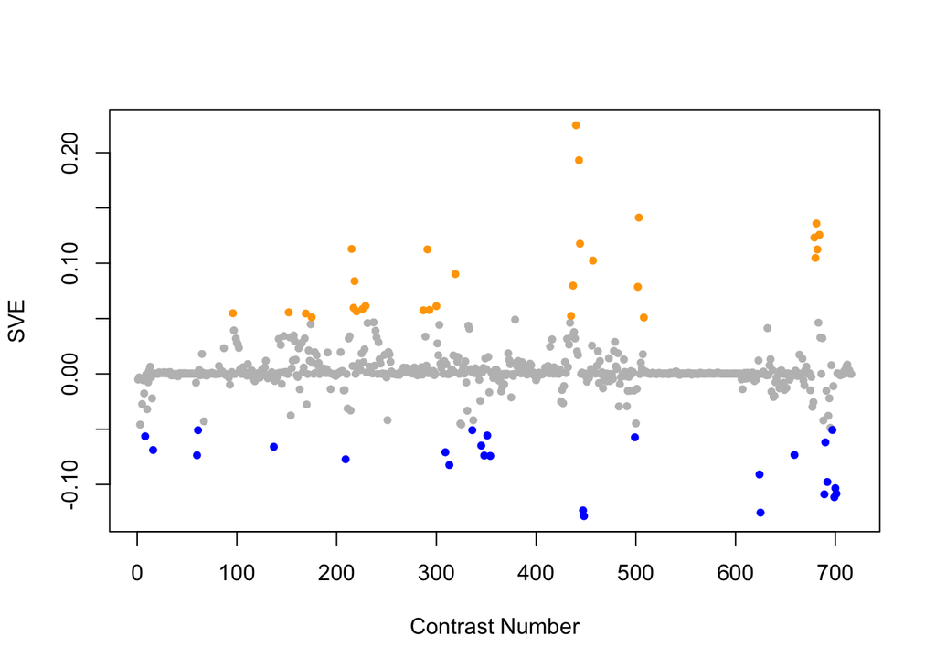

Positive SVE Contrasts:

|  | Contrast.Num | SVE | GEO.GSE | Cond.1 | Cond.2 | Mutation |
| --- | --- | --- | --- | --- | --- | --- |
| GSE27677B.s1t2.vs.s1t1 | 440 | 0.22 | GSE27677 | N2, Fast 3 h, rep 1 | N2, Fed 0 h, rep 1 |  |
| GSE27677B.s1t3.vs.s1t1 | 443 | 0.19 | GSE27677 | N2, Fast 6 h, rep 1 | N2, Fed 0 h, rep 1 |  |
| GSE22660.s1t2.vs.s0t2 | 503 | 0.14 | GSE22660 | 1ug/ml ivermectin exposure, biological rep 1 | 1ug/ml DMSO control, biological rep 1 |  |
| GSE12298A.s2t1.vs.s0t1 | 681 | 0.14 | GSE12298 | dichlorvos_mid_dose-rep1 | dichlorvos_control-rep1 |  |
| GSE12298B.s2t1.vs.s0t1 | 684 | 0.13 | GSE12298 | fenamiphos_mid_dose-rep1 | fenamiphos_control-rep1 |  |
| GSE12298A.s3t1.vs.s0t1 | 679 | 0.12 | GSE12298 | dichlorvos_high_dose-rep1 | dichlorvos_control-rep1 |  |
| GSE27677B.s1t4.vs.s1t1 | 444 | 0.12 | GSE27677 | N2, Fast 9 h, rep 1 | N2, Fed 0 h, rep 1 |  |
| GSE42592A.s3t2.vs.s0t2 | 215 | 0.11 | GSE42592 | acrylamide_high_expose-4h_rep1 | acrylamide_control_expose-4h_rep1 |  |
| GSE41366C.s2t2.vs.s0t2 | 291 | 0.11 | GSE41366 | high_DDVP-continuous_expose-8h_harvest-rep1 | control-continuous_expose-2h_harvest-rep1 |  |
| GSE12298B.s3t1.vs.s0t1 | 682 | 0.11 | GSE12298 | fenamiphos_high_dose-rep1 | fenamiphos_control-rep1 |  |
| GSE12298A.s1t1.vs.s0t1 | 680 | 0.10 | GSE12298 | dichlorvos_low_dose-rep1 | dichlorvos_control-rep1 |  |
| GSE24847.s1t3.vs.s1t1 | 457 | 0.10 | GSE24847 | young adult_4hr MWCNT exposure_rep1 | young adult_0h MWCNT exposure_rep1 |  |
| GSE39012.s1t1.vs.s0t1 | 319 | 0.09 | GSE39012 | L3 stage worm AS_.03, biological replicate 1 | L3 stage worm AS_Control, biological replicate 1 |  |
| GSE42592A.s3t3.vs.s0t3 | 218 | 0.08 | GSE42592 | acrylamide_high_expose-8h_rep1 | acrylamide_control_expose-8h_rep1 |  |
| GSE27677B.s1t5.vs.s1t1 | 437 | 0.08 | GSE27677 | N2, Fast 12 h, rep 1 | N2, Fed 0 h, rep 1 |  |
| GSE22660.s1t1.vs.s0t1 | 502 | 0.08 | GSE22660 | 100ng/ml ivermectin exposure, biological rep 1 | 100ng/ml DMSO control, biological rep 1 |  |
| GSE42592B.s3t3.vs.s0t3 | 229 | 0.06 | GSE42592 | cadmium_high_expose-8h_rep1 | cadmium_control_expose-8h_rep1 |  |
| GSE41366C.s2t3.vs.s2t1 | 300 | 0.06 | GSE41366 | high_DDVP-continuous_expose-14h_harvest-rep1 | high_DDVP-continuous_expose-2h_harvest-rep1 |  |
| GSE42592A.s2t2.vs.s0t2 | 217 | 0.06 | GSE42592 | acrylamide_mid_expose-4h_rep1 | acrylamide_control_expose-4h_rep1 |  |
| GSE42592B.s3t2.vs.s0t2 | 226 | 0.06 | GSE42592 | cadmium_high_expose-4h_rep1 | cadmium_control_expose-4h_rep1 |  |
| GSE41366C.s2t3.vs.s0t3 | 293 | 0.06 | GSE41366 | high_DDVP-continuous_expose-14h_harvest-rep1 | control-continuous_expose-8h_harvest-rep1 |  |
| GSE41366C.s2t4.vs.s0t4 | 287 | 0.06 | GSE41366 | high_DDVP-continuous_expose-20h_harvest-rep1 | control-continuous_expose-14h_harvest-rep1 |  |
| GSE42592A.s2t3.vs.s0t3 | 220 | 0.06 | GSE42592 | acrylamide_mid_expose-8h_rep1 | acrylamide_control_expose-8h_rep1 |  |
| GSE47778.s1t1.vs.s3t1 | 152 | 0.06 | GSE47778 | N2; replicate 1 | daf-16; replicate 1 | daf-16 |
| GSE5793.s3t1.vs.s1t1 | 96 | 0.05 | GSE5793 | Celegans_PA14_4hours_RepA | Celegans_gacA_4hours_RepA |  |
| GSE47778.s5t3.vs.s3t3 | 169 | 0.05 | GSE47778 | xpa-1 10mJ/cm2; replicate 1 | daf-16; UV; replicate 1 | xpa-1 vs. daf-16 |
| GSE27677B.s1t7.vs.s0t7 | 435 | 0.05 | GSE27677 | N2, Fast 24 h, rep 1 | N2, Fed 24 h, rep 1 |  |
| GSE47778.s5t3.vs.s1t3 | 175 | 0.05 | GSE47778 | xpa-1 10mJ/cm2; replicate 1 | N2; UV; replicate 1 | xpa-1 |
| GSE21819.s1t1.vs.s0t1 | 508 | 0.05 | GSE21819 | CELEGANS_RN6390_8H_REP1 | CELEGANS_OP50_8H_REP1 |  |

Negative SVE Contrasts:

|  | Contrast.Num | SVE | GEO.GSE | Cond.1 | Cond.2 | Mutation |
| --- | --- | --- | --- | --- | --- | --- |
| GSE27401.s1t1.vs.s2t1 | 448 | -0.13 | GSE27401 | Heat Killed E coli #1 | Heat Killed C. albicans #1 |  |
| GSE19972.s2t1.vs.s0t1 | 625 | -0.13 | GSE19972 | transgenic myo-4::his-SUMO-1 JS63_1 | control wild type N2_1 |  |
| GSE27401.s1t1.vs.s3t1 | 447 | -0.12 | GSE27401 | Heat Killed E coli #1 | C. albicans alive #1 |  |
| GSE11055.s1t4.vs.s2t4 | 699 | -0.11 | GSE11055 | L1 larvae 3 hr after hatching in the presence of food | L1 larvae 3 hr after hatching in the absence of food |  |
| GSE11055.s1t3.vs.s2t3 | 689 | -0.11 | GSE11055 | L1 larvae 1 hr after hatching in the presence of food | L1 larvae 1 hr after hatching in the absence of food |  |
| GSE11055.s1t5.vs.s2t5 | 701 | -0.11 | GSE11055 | L1 larvae 6 hr after hatching in the presence of food | L1 larvae 6 hr after hatching in the absence of food |  |
| GSE11055.s1t4.vs.s3t4 | 700 | -0.10 | GSE11055 | L1 larvae 3 hr after hatching in the presence of food | L1 larvae 3 hr after hatching in the absence of food in the alternative starvation buffer M9 |  |
| GSE11055.s5t7.vs.s2t7 | 692 | -0.10 | GSE11055 | L1 larvae starved for 12 hr after hatching and then fed for 3 hr | L1 larvae 15 hr after hatching in the absence of food |  |
| GSE19972.s1t1.vs.s0t1 | 624 | -0.09 | GSE19972 | transgenic aex-3::his-SUMO-1 JS62_1 | control wild type N2_1 |  |
| GSE41056.s0t2.vs.s0t1 | 313 | -0.08 | GSE41056 | N2_inf_1 | N2_1 |  |
| GSE42689.s2t1.vs.s1t1 | 209 | -0.08 | GSE42689 | mek-1 fed 1 | mek-1 fasted 1 |  |
| GSE38997.s4t4.vs.s4t1 | 354 | -0.07 | GSE38997 | experiment 1 UVC-exposed samples at 51 h 1u51 | experiment 4 UVC-exposed samples at 3 h 4u3 |  |
| GSE38997.s2t4.vs.s2t1 | 348 | -0.07 | GSE38997 | experiment 1 EtBr-exposed samples at 51 h 1e51 | experiment 4 EtBr-exposed samples at 3 h 4e3 |  |
| GSE9301.s3t1.vs.s1t1 | 60 | -0.07 | GSE9301 | 3-day-old TJ1090 worms without any stress (C1) | 3-day-old TJ1090 worms with oxidative stress (O1) |  |
| GSE15762.s1t1.vs.s0t1 | 659 | -0.07 | GSE15762 | hlh-30(tm1978)-1 | N2-1 | hlh-30 |
| GSE41056.s2t1.vs.s0t1 | 309 | -0.07 | GSE41056 | RDE_1_1 | N2_1 | rde-1 |
| GSE9682.s0t2.vs.s0t1 | 16 | -0.07 | GSE9682 | N2-controlRNAi-fed-biological rep1 | N2-controlRNAi-fasting-biological rep1 |  |
| GSE51691.s3t1.vs.s1t1 | 137 | -0.07 | GSE51691 | day8 hermaphrodite utx-1 RNAi -males rep 1 | day8 hermaphrodite -males rep 1 | utx-1(RNAi) |
| GSE38997.s1t4.vs.s1t1 | 345 | -0.06 | GSE38997 | experiment 1 control samples at 51 h 1c51 | experiment 4 control samples at 3 h 4c3 |  |
| GSE11055.s1t6.vs.s2t6 | 690 | -0.06 | GSE11055 | L1 larvae 12 hr after hatching in the presence of food | L1 larvae 12 hr after hatching in the absence of food |  |
| GSE23013.s3t1.vs.s0t1 | 499 | -0.06 | GSE23013 | young adult_24hr BTF mix exposure_rep1 | young adult_not exposed_rep1 |  |
| GSE9897B.s5t1.vs.s0t1 | 8 | -0.06 | GSE9897 | Complex I RNAi Mutant 5 | Wildtype (control for RNAi) | D2030.4 |
| GSE38997.s3t4.vs.s3t1 | 351 | -0.06 | GSE38997 | experiment 1 UVC- and EtBr-exposed samples at 51 h 1eu51 | experiment 4 UVC- and EtBr-exposed samples at 3 h 4eu3 |  |
| GSE9301.s3t1.vs.s2t1 | 61 | -0.05 | GSE9301 | 3-day-old TJ1090 worms without any stress (C1) | 3-day-old TJ1090 worms with skn-1 RNAi & oxidative stress (SO1) |  |
| GSE38997.s4t2.vs.s2t2 | 336 | -0.05 | GSE38997 | experiment 4 UVC-exposed samples at 24 h 4u24 | experiment 4 EtBr-exposed samples at 24 h 4e24 |  |
| GSE11055.s1t8.vs.s2t8 | 697 | -0.05 | GSE11055 | L2 larvae 24 hr after hatching in the presence of food | L1 larvae 24 hr after hatching in the absence of food |  |

$~$

$~$

#### GO Term Enrichment:

This analysis tests each hemi-module for enrichment of specific GO terms. Only gene-level annotations (e.g., as would be found on the gene’s page in Wormbase) are tested - the hierarchical structure of the GO ontology is not taken into account.

*Note: At least the top two most enriched terms from each GO domain (BP/MF/CC) are shown, even when not statistically significant.*

##### Enriched GO terms: Hemi-module A

| ID | GO.Term | GO Domain | Raw p-value | Adj p-value |
| --- | --- | --- | --- | --- |
| [GO_0006082](http://amigo.geneontology.org/amigo/term/GO:0006082) | organic acid metabolic process | BP | 1.60e-06 | 2.62e-03 |
| [GO_0042738](http://amigo.geneontology.org/amigo/term/GO:0042738) | exogenous drug catabolic process | BP | 1.60e-06 | 2.62e-03 |
| [GO_0006805](http://amigo.geneontology.org/amigo/term/GO:0006805) | xenobiotic metabolic process | BP | 2.15e-06 | 2.62e-03 |
| [GO_0055114](http://amigo.geneontology.org/amigo/term/GO:0055114) | oxidation-reduction process | BP | 1.69e-05 | 1.53e-02 |
| [GO_0004497](http://amigo.geneontology.org/amigo/term/GO:0004497) | monooxygenase activity | MF | 1.20e-07 | 1.36e-04 |
| [GO_0008194](http://amigo.geneontology.org/amigo/term/GO:0008194) | UDP-glycosyltransferase activity | MF | 1.33e-07 | 1.36e-04 |
| [GO_0016758](http://amigo.geneontology.org/amigo/term/GO:0016758) | transferase activity, transferring hexosyl groups | MF | 2.98e-07 | 2.03e-04 |
| [GO_0016705](http://amigo.geneontology.org/amigo/term/GO:0016705) | oxidoreductase activity, acting on paired donors, with incorporation or reduction of molecular oxygen | MF | 6.80e-07 | 3.47e-04 |
| [GO_0005506](http://amigo.geneontology.org/amigo/term/GO:0005506) | iron ion binding | MF | 8.68e-07 | 3.55e-04 |
| [GO_0008395](http://amigo.geneontology.org/amigo/term/GO:0008395) | steroid hydroxylase activity | MF | 1.60e-06 | 5.43e-04 |
| [GO_0016712](http://amigo.geneontology.org/amigo/term/GO:0016712) | oxidoreductase activity, acting on paired donors, with incorporation or reduction of molecular oxygen, reduced flavin or flavoprotein as one donor, and incorporation of one atom of oxygen | MF | 1.86e-06 | 5.43e-04 |
| [GO_0016491](http://amigo.geneontology.org/amigo/term/GO:0016491) | oxidoreductase activity | MF | 3.71e-05 | 9.47e-03 |
| [GO_0020037](http://amigo.geneontology.org/amigo/term/GO:0020037) | heme binding | MF | 5.15e-05 | 1.17e-02 |
| [GO_0005515](http://amigo.geneontology.org/amigo/term/GO:0005515) | protein binding | MF | 3.93e-04 | 8.02e-02 |
| [GO_0043231](http://amigo.geneontology.org/amigo/term/GO:0043231) | intracellular membrane-bounded organelle | CC | 6.56e-12 | 6.09e-09 |
| [GO_0005634](http://amigo.geneontology.org/amigo/term/GO:0005634) | nucleus | CC | 5.86e-05 | 2.72e-02 |

##### Enriched GO terms: Hemi-module B

| ID | GO.Term | GO Domain | Raw p-value | Adj p-value |
| --- | --- | --- | --- | --- |
| [GO_0055085](http://amigo.geneontology.org/amigo/term/GO:0055085) | transmembrane transport | BP | 3.85e-06 | 1.40e-02 |
| [GO_0051453](http://amigo.geneontology.org/amigo/term/GO:0051453) | regulation of intracellular pH | BP | 2.54e-04 | 3.14e-01 |
| [GO_0030170](http://amigo.geneontology.org/amigo/term/GO:0030170) | pyridoxal phosphate binding | MF | 2.60e-08 | 5.31e-05 |
| [GO_0003824](http://amigo.geneontology.org/amigo/term/GO:0003824) | catalytic activity | MF | 7.14e-05 | 7.30e-02 |
| [GO_0004758](http://amigo.geneontology.org/amigo/term/GO:0004758) | serine C-palmitoyltransferase activity | MF | 1.30e-04 | 8.78e-02 |
| [GO_0016740](http://amigo.geneontology.org/amigo/term/GO:0016740) | transferase activity | MF | 2.03e-04 | 8.78e-02 |
| [GO_0015297](http://amigo.geneontology.org/amigo/term/GO:0015297) | antiporter activity | MF | 2.15e-04 | 8.78e-02 |
| [GO_0005634](http://amigo.geneontology.org/amigo/term/GO:0005634) | nucleus | CC | 2.81e-04 | 2.60e-01 |
| [GO_0016324](http://amigo.geneontology.org/amigo/term/GO:0016324) | apical plasma membrane | CC | 1.32e-03 | 6.14e-01 |

$~$

$~$

#### Tissue Enrichment:

This analysis tests each hemi-module for enrichment of genes associated with anatomy terms. Negative enrichment scores indicate fewer hemi-module genes than expected by random chance were associated with the anatomy term in question.

##### Enriched tissues: Hemi-module A

No significant annotations.

##### Enriched tissues: Hemi-module B

No significant annotations.

$~$

$~$

#### HOMER promoter motif enrichment:

This analysis tests each hemi-module for enrichment of 108 known *C. elegans* transcription factor binding site motifs (see [108 CE motifs](https://katiepod.github.io//all.worm.motifs.html)) using the HOMER (Hypergeometric Optimization of Motif EnRichment) software (see [PMID:20513432](https://pubmed.ncbi.nlm.nih.gov/20513432)). HOMER was run using default parameters on sequences 1 kb upstream of the transcription start site.

##### Motif enrichment: Hemi-module A

Total target sequences = 146  
Total background sequences = 42402  
* - possible false positive

Rank

Motif

P-value

log P-pvalue

% of Targets

% of Background

STD(Bg STD)

Best Match/Details

Motif File

1

[figure not shown]

1e-25

-5.976e+01

68.49%

26.02%

271.1bp (325.9bp)

elt-2/MA1701.1/Jaspar(0.984)  
[More Information](https://katiepod.github.io/HomerResults/m149_a_hemi_genes.txt.out.1kb/homerResults/motif1.info.html) | [Similar Motifs Found](https://katiepod.github.io/HomerResults/m149_a_hemi_genes.txt.out.1kb/homerResults/motif1.similar.html)

[motif file (matrix)](https://katiepod.github.io/HomerResults/m149_a_hemi_genes.txt.out.1kb/homerResults/motif1.motif)

2

[figure not shown]

1e-13

-3.098e+01

9.59%

0.48%

350.3bp (327.1bp)

POL012.1_TATA-Box/Jaspar(0.775)  
[More Information](https://katiepod.github.io/HomerResults/m149_a_hemi_genes.txt.out.1kb/homerResults/motif2.info.html) | [Similar Motifs Found](https://katiepod.github.io/HomerResults/m149_a_hemi_genes.txt.out.1kb/homerResults/motif2.similar.html)

[motif file (matrix)](https://katiepod.github.io/HomerResults/m149_a_hemi_genes.txt.out.1kb/homerResults/motif2.motif)

3

[figure not shown]

1e-12

-2.859e+01

10.27%

0.71%

259.9bp (317.4bp)

POL012.1_TATA-Box/Jaspar(0.685)  
[More Information](https://katiepod.github.io/HomerResults/m149_a_hemi_genes.txt.out.1kb/homerResults/motif3.info.html) | [Similar Motifs Found](https://katiepod.github.io/HomerResults/m149_a_hemi_genes.txt.out.1kb/homerResults/motif3.similar.html)

[motif file (matrix)](https://katiepod.github.io/HomerResults/m149_a_hemi_genes.txt.out.1kb/homerResults/motif3.motif)

4

[figure not shown]

1e-12

-2.836e+01

26.71%

7.14%

286.4bp (309.8bp)

PHA-4(Forkhead)/cElegans-Embryos-PHA4-ChIP-Seq(modEncode)/Homer(0.774)  
[More Information](https://katiepod.github.io/HomerResults/m149_a_hemi_genes.txt.out.1kb/homerResults/motif4.info.html) | [Similar Motifs Found](https://katiepod.github.io/HomerResults/m149_a_hemi_genes.txt.out.1kb/homerResults/motif4.similar.html)

[motif file (matrix)](https://katiepod.github.io/HomerResults/m149_a_hemi_genes.txt.out.1kb/homerResults/motif4.motif)

5 *

[figure not shown]

1e-11

-2.729e+01

24.66%

6.31%

281.9bp (324.6bp)

PL0001.1_hlh-11/Jaspar(0.903)  
[More Information](https://katiepod.github.io/HomerResults/m149_a_hemi_genes.txt.out.1kb/homerResults/motif5.info.html) | [Similar Motifs Found](https://katiepod.github.io/HomerResults/m149_a_hemi_genes.txt.out.1kb/homerResults/motif5.similar.html)

[motif file (matrix)](https://katiepod.github.io/HomerResults/m149_a_hemi_genes.txt.out.1kb/homerResults/motif5.motif)

6 *

[figure not shown]

1e-10

-2.483e+01

13.70%

1.96%

290.6bp (323.5bp)

PHA-4(Forkhead)/cElegans-Embryos-PHA4-ChIP-Seq(modEncode)/Homer(0.643)  
[More Information](https://katiepod.github.io/HomerResults/m149_a_hemi_genes.txt.out.1kb/homerResults/motif6.info.html) | [Similar Motifs Found](https://katiepod.github.io/HomerResults/m149_a_hemi_genes.txt.out.1kb/homerResults/motif6.similar.html)

[motif file (matrix)](https://katiepod.github.io/HomerResults/m149_a_hemi_genes.txt.out.1kb/homerResults/motif6.motif)

7 *

[figure not shown]

1e-10

-2.457e+01

11.64%

1.33%

294.1bp (306.9bp)

ceh-48/MA0921.1/Jaspar(0.610)  
[More Information](https://katiepod.github.io/HomerResults/m149_a_hemi_genes.txt.out.1kb/homerResults/motif7.info.html) | [Similar Motifs Found](https://katiepod.github.io/HomerResults/m149_a_hemi_genes.txt.out.1kb/homerResults/motif7.similar.html)

[motif file (matrix)](https://katiepod.github.io/HomerResults/m149_a_hemi_genes.txt.out.1kb/homerResults/motif7.motif)

8 *

[figure not shown]

1e-10

-2.397e+01

6.85%

0.29%

309.3bp (318.0bp)

lin-54/MA1450.1/Jaspar(0.675)  
[More Information](https://katiepod.github.io/HomerResults/m149_a_hemi_genes.txt.out.1kb/homerResults/motif8.info.html) | [Similar Motifs Found](https://katiepod.github.io/HomerResults/m149_a_hemi_genes.txt.out.1kb/homerResults/motif8.similar.html)

[motif file (matrix)](https://katiepod.github.io/HomerResults/m149_a_hemi_genes.txt.out.1kb/homerResults/motif8.motif)

9 *

[figure not shown]

1e-10

-2.304e+01

6.85%

0.32%

277.4bp (283.5bp)

MF0001.1_ETS_class/Jaspar(0.625)  
[More Information](https://katiepod.github.io/HomerResults/m149_a_hemi_genes.txt.out.1kb/homerResults/motif9.info.html) | [Similar Motifs Found](https://katiepod.github.io/HomerResults/m149_a_hemi_genes.txt.out.1kb/homerResults/motif9.similar.html)

[motif file (matrix)](https://katiepod.github.io/HomerResults/m149_a_hemi_genes.txt.out.1kb/homerResults/motif9.motif)

10 *

[figure not shown]

1e-9

-2.235e+01

8.90%

0.77%

247.8bp (330.9bp)

sma-4/MA0925.1/Jaspar(0.590)  
[More Information](https://katiepod.github.io/HomerResults/m149_a_hemi_genes.txt.out.1kb/homerResults/motif10.info.html) | [Similar Motifs Found](https://katiepod.github.io/HomerResults/m149_a_hemi_genes.txt.out.1kb/homerResults/motif10.similar.html)

[motif file (matrix)](https://katiepod.github.io/HomerResults/m149_a_hemi_genes.txt.out.1kb/homerResults/motif10.motif)

11 *

[figure not shown]

1e-9

-2.235e+01

10.96%

1.33%

273.2bp (326.1bp)

MF0010.1_Homeobox_class/Jaspar(0.616)  
[More Information](https://katiepod.github.io/HomerResults/m149_a_hemi_genes.txt.out.1kb/homerResults/motif11.info.html) | [Similar Motifs Found](https://katiepod.github.io/HomerResults/m149_a_hemi_genes.txt.out.1kb/homerResults/motif11.similar.html)

[motif file (matrix)](https://katiepod.github.io/HomerResults/m149_a_hemi_genes.txt.out.1kb/homerResults/motif11.motif)

12 *

[figure not shown]

1e-9

-2.196e+01

20.55%

5.41%

238.5bp (313.2bp)

zip-8/MA1704.1/Jaspar(0.906)  
[More Information](https://katiepod.github.io/HomerResults/m149_a_hemi_genes.txt.out.1kb/homerResults/motif12.info.html) | [Similar Motifs Found](https://katiepod.github.io/HomerResults/m149_a_hemi_genes.txt.out.1kb/homerResults/motif12.similar.html)

[motif file (matrix)](https://katiepod.github.io/HomerResults/m149_a_hemi_genes.txt.out.1kb/homerResults/motif12.motif)

13 *

[figure not shown]

1e-9

-2.187e+01

4.79%

0.10%

269.8bp (267.4bp)

MF0003.1_REL_class/Jaspar(0.589)  
[More Information](https://katiepod.github.io/HomerResults/m149_a_hemi_genes.txt.out.1kb/homerResults/motif13.info.html) | [Similar Motifs Found](https://katiepod.github.io/HomerResults/m149_a_hemi_genes.txt.out.1kb/homerResults/motif13.similar.html)

[motif file (matrix)](https://katiepod.github.io/HomerResults/m149_a_hemi_genes.txt.out.1kb/homerResults/motif13.motif)

14 *

[figure not shown]

1e-9

-2.146e+01

7.53%

0.51%

285.0bp (308.9bp)

fkh-9/MA1440.1/Jaspar(0.633)  
[More Information](https://katiepod.github.io/HomerResults/m149_a_hemi_genes.txt.out.1kb/homerResults/motif14.info.html) | [Similar Motifs Found](https://katiepod.github.io/HomerResults/m149_a_hemi_genes.txt.out.1kb/homerResults/motif14.similar.html)

[motif file (matrix)](https://katiepod.github.io/HomerResults/m149_a_hemi_genes.txt.out.1kb/homerResults/motif14.motif)

15 *

[figure not shown]

1e-9

-2.101e+01

4.79%

0.11%

280.9bp (328.9bp)

fos-1/MA1448.1/Jaspar(0.607)  
[More Information](https://katiepod.github.io/HomerResults/m149_a_hemi_genes.txt.out.1kb/homerResults/motif15.info.html) | [Similar Motifs Found](https://katiepod.github.io/HomerResults/m149_a_hemi_genes.txt.out.1kb/homerResults/motif15.similar.html)

[motif file (matrix)](https://katiepod.github.io/HomerResults/m149_a_hemi_genes.txt.out.1kb/homerResults/motif15.motif)

16 *

[figure not shown]

1e-8

-2.037e+01

7.53%

0.57%

217.7bp (281.7bp)

MF0010.1_Homeobox_class/Jaspar(0.610)  
[More Information](https://katiepod.github.io/HomerResults/m149_a_hemi_genes.txt.out.1kb/homerResults/motif16.info.html) | [Similar Motifs Found](https://katiepod.github.io/HomerResults/m149_a_hemi_genes.txt.out.1kb/homerResults/motif16.similar.html)

[motif file (matrix)](https://katiepod.github.io/HomerResults/m149_a_hemi_genes.txt.out.1kb/homerResults/motif16.motif)

17 *

[figure not shown]

1e-8

-1.976e+01

19.18%

5.22%

284.0bp (301.3bp)

DPL-1(E2F)/cElegans-Adult-ChIP-Seq(modEncode)/Homer(0.548)  
[More Information](https://katiepod.github.io/HomerResults/m149_a_hemi_genes.txt.out.1kb/homerResults/motif17.info.html) | [Similar Motifs Found](https://katiepod.github.io/HomerResults/m149_a_hemi_genes.txt.out.1kb/homerResults/motif17.similar.html)

[motif file (matrix)](https://katiepod.github.io/HomerResults/m149_a_hemi_genes.txt.out.1kb/homerResults/motif17.motif)

18 *

[figure not shown]

1e-8

-1.928e+01

8.90%

1.00%

259.3bp (292.6bp)

fkh-2/MA0920.1/Jaspar(0.589)  
[More Information](https://katiepod.github.io/HomerResults/m149_a_hemi_genes.txt.out.1kb/homerResults/motif18.info.html) | [Similar Motifs Found](https://katiepod.github.io/HomerResults/m149_a_hemi_genes.txt.out.1kb/homerResults/motif18.similar.html)

[motif file (matrix)](https://katiepod.github.io/HomerResults/m149_a_hemi_genes.txt.out.1kb/homerResults/motif18.motif)

19 *

[figure not shown]

1e-8

-1.887e+01

14.38%

3.09%

301.7bp (313.7bp)

POL003.1_GC-box/Jaspar(0.524)  
[More Information](https://katiepod.github.io/HomerResults/m149_a_hemi_genes.txt.out.1kb/homerResults/motif19.info.html) | [Similar Motifs Found](https://katiepod.github.io/HomerResults/m149_a_hemi_genes.txt.out.1kb/homerResults/motif19.similar.html)

[motif file (matrix)](https://katiepod.github.io/HomerResults/m149_a_hemi_genes.txt.out.1kb/homerResults/motif19.motif)

20 *

[figure not shown]

1e-7

-1.784e+01

3.42%

0.05%

233.1bp (276.6bp)

daf-16/MA1446.1/Jaspar(0.597)  
[More Information](https://katiepod.github.io/HomerResults/m149_a_hemi_genes.txt.out.1kb/homerResults/motif20.info.html) | [Similar Motifs Found](https://katiepod.github.io/HomerResults/m149_a_hemi_genes.txt.out.1kb/homerResults/motif20.similar.html)

[motif file (matrix)](https://katiepod.github.io/HomerResults/m149_a_hemi_genes.txt.out.1kb/homerResults/motif20.motif)

21 *

[figure not shown]

1e-7

-1.769e+01

4.79%

0.19%

252.7bp (301.4bp)

SD0001.1_at_AC_acceptor/Jaspar(0.512)  
[More Information](https://katiepod.github.io/HomerResults/m149_a_hemi_genes.txt.out.1kb/homerResults/motif21.info.html) | [Similar Motifs Found](https://katiepod.github.io/HomerResults/m149_a_hemi_genes.txt.out.1kb/homerResults/motif21.similar.html)

[motif file (matrix)](https://katiepod.github.io/HomerResults/m149_a_hemi_genes.txt.out.1kb/homerResults/motif21.motif)

22 *

[figure not shown]

1e-7

-1.718e+01

13.01%

2.79%

258.3bp (307.8bp)

MF0004.1_Nuclear_Receptor_class/Jaspar(0.637)  
[More Information](https://katiepod.github.io/HomerResults/m149_a_hemi_genes.txt.out.1kb/homerResults/motif22.info.html) | [Similar Motifs Found](https://katiepod.github.io/HomerResults/m149_a_hemi_genes.txt.out.1kb/homerResults/motif22.similar.html)

[motif file (matrix)](https://katiepod.github.io/HomerResults/m149_a_hemi_genes.txt.out.1kb/homerResults/motif22.motif)

23 *

[figure not shown]

1e-7

-1.666e+01

8.22%

1.03%

316.0bp (317.9bp)

PL0007.1_mxl-3/Jaspar(0.570)  
[More Information](https://katiepod.github.io/HomerResults/m149_a_hemi_genes.txt.out.1kb/homerResults/motif23.info.html) | [Similar Motifs Found](https://katiepod.github.io/HomerResults/m149_a_hemi_genes.txt.out.1kb/homerResults/motif23.similar.html)

[motif file (matrix)](https://katiepod.github.io/HomerResults/m149_a_hemi_genes.txt.out.1kb/homerResults/motif23.motif)

24 *

[figure not shown]

1e-6

-1.611e+01

4.79%

0.24%

263.6bp (288.7bp)

LIN-39(Homeobox)/cElegans.L3-LIN39-ChIP-Seq(modEncode)/Homer(0.618)  
[More Information](https://katiepod.github.io/HomerResults/m149_a_hemi_genes.txt.out.1kb/homerResults/motif24.info.html) | [Similar Motifs Found](https://katiepod.github.io/HomerResults/m149_a_hemi_genes.txt.out.1kb/homerResults/motif24.similar.html)

[motif file (matrix)](https://katiepod.github.io/HomerResults/m149_a_hemi_genes.txt.out.1kb/homerResults/motif24.motif)

25 *

[figure not shown]

1e-6

-1.566e+01

11.64%

2.46%

252.0bp (309.7bp)

ceh-38/MA1699.1/Jaspar(0.618)  
[More Information](https://katiepod.github.io/HomerResults/m149_a_hemi_genes.txt.out.1kb/homerResults/motif25.info.html) | [Similar Motifs Found](https://katiepod.github.io/HomerResults/m149_a_hemi_genes.txt.out.1kb/homerResults/motif25.similar.html)

[motif file (matrix)](https://katiepod.github.io/HomerResults/m149_a_hemi_genes.txt.out.1kb/homerResults/motif25.motif)

26 *

[figure not shown]

1e-6

-1.548e+01

10.27%

1.92%

230.1bp (305.0bp)

unc-86/MA0926.1/Jaspar(0.659)  
[More Information](https://katiepod.github.io/HomerResults/m149_a_hemi_genes.txt.out.1kb/homerResults/motif26.info.html) | [Similar Motifs Found](https://katiepod.github.io/HomerResults/m149_a_hemi_genes.txt.out.1kb/homerResults/motif26.similar.html)

[motif file (matrix)](https://katiepod.github.io/HomerResults/m149_a_hemi_genes.txt.out.1kb/homerResults/motif26.motif)

27 *

[figure not shown]

1e-6

-1.527e+01

2.74%

0.03%

239.6bp (206.8bp)

DPL-1(E2F)/cElegans-Adult-ChIP-Seq(modEncode)/Homer(0.574)  
[More Information](https://katiepod.github.io/HomerResults/m149_a_hemi_genes.txt.out.1kb/homerResults/motif27.info.html) | [Similar Motifs Found](https://katiepod.github.io/HomerResults/m149_a_hemi_genes.txt.out.1kb/homerResults/motif27.similar.html)

[motif file (matrix)](https://katiepod.github.io/HomerResults/m149_a_hemi_genes.txt.out.1kb/homerResults/motif27.motif)

28 *

[figure not shown]

1e-5

-1.341e+01

14.38%

4.31%

305.0bp (313.2bp)

hlh-30/MA1449.1/Jaspar(0.757)  
[More Information](https://katiepod.github.io/HomerResults/m149_a_hemi_genes.txt.out.1kb/homerResults/motif28.info.html) | [Similar Motifs Found](https://katiepod.github.io/HomerResults/m149_a_hemi_genes.txt.out.1kb/homerResults/motif28.similar.html)

[motif file (matrix)](https://katiepod.github.io/HomerResults/m149_a_hemi_genes.txt.out.1kb/homerResults/motif28.motif)

29 *

[figure not shown]

1e-5

-1.153e+01

4.11%

0.32%

275.3bp (280.2bp)

unc-30/MA1443.1/Jaspar(0.513)  
[More Information](https://katiepod.github.io/HomerResults/m149_a_hemi_genes.txt.out.1kb/homerResults/motif29.info.html) | [Similar Motifs Found](https://katiepod.github.io/HomerResults/m149_a_hemi_genes.txt.out.1kb/homerResults/motif29.similar.html)

[motif file (matrix)](https://katiepod.github.io/HomerResults/m149_a_hemi_genes.txt.out.1kb/homerResults/motif29.motif)

30 *

[figure not shown]

1e-4

-1.137e+01

10.96%

3.04%

256.1bp (310.1bp)

PL0012.1_hlh-2::hlh-8/Jaspar(0.591)  
[More Information](https://katiepod.github.io/HomerResults/m149_a_hemi_genes.txt.out.1kb/homerResults/motif30.info.html) | [Similar Motifs Found](https://katiepod.github.io/HomerResults/m149_a_hemi_genes.txt.out.1kb/homerResults/motif30.similar.html)

[motif file (matrix)](https://katiepod.github.io/HomerResults/m149_a_hemi_genes.txt.out.1kb/homerResults/motif30.motif)

31 *

[figure not shown]

1e-4

-1.075e+01

2.05%

0.03%

121.2bp (185.3bp)

EGL-5(Homeobox)/cElegans-L3-EGL5-ChIP-Seq(modEncode)/Homer(0.638)  
[More Information](https://katiepod.github.io/HomerResults/m149_a_hemi_genes.txt.out.1kb/homerResults/motif31.info.html) | [Similar Motifs Found](https://katiepod.github.io/HomerResults/m149_a_hemi_genes.txt.out.1kb/homerResults/motif31.similar.html)

[motif file (matrix)](https://katiepod.github.io/HomerResults/m149_a_hemi_genes.txt.out.1kb/homerResults/motif31.motif)

32 *

[figure not shown]

1e-4

-9.772e+00

8.22%

2.05%

266.4bp (300.8bp)

nhr-6/MA1451.1/Jaspar(0.633)  
[More Information](https://katiepod.github.io/HomerResults/m149_a_hemi_genes.txt.out.1kb/homerResults/motif32.info.html) | [Similar Motifs Found](https://katiepod.github.io/HomerResults/m149_a_hemi_genes.txt.out.1kb/homerResults/motif32.similar.html)

[motif file (matrix)](https://katiepod.github.io/HomerResults/m149_a_hemi_genes.txt.out.1kb/homerResults/motif32.motif)

33 *

[figure not shown]

1e-3

-8.230e+00

3.42%

0.37%

204.0bp (289.7bp)

POL004.1_CCAAT-box/Jaspar(0.632)  
[More Information](https://katiepod.github.io/HomerResults/m149_a_hemi_genes.txt.out.1kb/homerResults/motif33.info.html) | [Similar Motifs Found](https://katiepod.github.io/HomerResults/m149_a_hemi_genes.txt.out.1kb/homerResults/motif33.similar.html)

[motif file (matrix)](https://katiepod.github.io/HomerResults/m149_a_hemi_genes.txt.out.1kb/homerResults/motif33.motif)

34 *

[figure not shown]

1e-2

-5.675e+00

0.68%

0.00%

100.6bp (0.0bp)

unc-30/MA1443.1/Jaspar(0.535)  
[More Information](https://katiepod.github.io/HomerResults/m149_a_hemi_genes.txt.out.1kb/homerResults/motif34.info.html) | [Similar Motifs Found](https://katiepod.github.io/HomerResults/m149_a_hemi_genes.txt.out.1kb/homerResults/motif34.similar.html)

[motif file (matrix)](https://katiepod.github.io/HomerResults/m149_a_hemi_genes.txt.out.1kb/homerResults/motif34.motif)

35 *

[figure not shown]

1e-2

-5.675e+00

0.68%

0.00%

237.6bp (0.0bp)

PL0017.1_hlh-2::hlh-10/Jaspar(0.634)  
[More Information](https://katiepod.github.io/HomerResults/m149_a_hemi_genes.txt.out.1kb/homerResults/motif35.info.html) | [Similar Motifs Found](https://katiepod.github.io/HomerResults/m149_a_hemi_genes.txt.out.1kb/homerResults/motif35.similar.html)

[motif file (matrix)](https://katiepod.github.io/HomerResults/m149_a_hemi_genes.txt.out.1kb/homerResults/motif35.motif)

36 *

[figure not shown]

1e-2

-4.983e+00

0.68%

0.00%

237.6bp (0.0bp)

SD0003.1_at_AC_acceptor/Jaspar(0.660)  
[More Information](https://katiepod.github.io/HomerResults/m149_a_hemi_genes.txt.out.1kb/homerResults/motif36.info.html) | [Similar Motifs Found](https://katiepod.github.io/HomerResults/m149_a_hemi_genes.txt.out.1kb/homerResults/motif36.similar.html)

[motif file (matrix)](https://katiepod.github.io/HomerResults/m149_a_hemi_genes.txt.out.1kb/homerResults/motif36.motif)

##### Motif enrichment: Hemi-module B

Total target sequences = 104  
Total background sequences = 39793  
* - possible false positive

Rank

Motif

P-value

log P-pvalue

% of Targets

% of Background

STD(Bg STD)

Best Match/Details

Motif File

1 *

[figure not shown]

1e-11

-2.706e+01

20.19%

2.82%

326.1bp (308.0bp)

pqm-1/MA1703.1/Jaspar(0.887)  
[More Information](https://katiepod.github.io/HomerResults/m149_b_hemi_genes.txt.out.1kb/homerResults/motif1.info.html) | [Similar Motifs Found](https://katiepod.github.io/HomerResults/m149_b_hemi_genes.txt.out.1kb/homerResults/motif1.similar.html)

[motif file (matrix)](https://katiepod.github.io/HomerResults/m149_b_hemi_genes.txt.out.1kb/homerResults/motif1.motif)

2 *

[figure not shown]

1e-11

-2.583e+01

14.42%

1.26%

259.8bp (295.6bp)

sma-4/MA0925.1/Jaspar(0.631)  
[More Information](https://katiepod.github.io/HomerResults/m149_b_hemi_genes.txt.out.1kb/homerResults/motif2.info.html) | [Similar Motifs Found](https://katiepod.github.io/HomerResults/m149_b_hemi_genes.txt.out.1kb/homerResults/motif2.similar.html)

[motif file (matrix)](https://katiepod.github.io/HomerResults/m149_b_hemi_genes.txt.out.1kb/homerResults/motif2.motif)

3 *

[figure not shown]

1e-10

-2.516e+01

7.69%

0.15%

199.2bp (342.5bp)

MF0004.1_Nuclear_Receptor_class/Jaspar(0.525)  
[More Information](https://katiepod.github.io/HomerResults/m149_b_hemi_genes.txt.out.1kb/homerResults/motif3.info.html) | [Similar Motifs Found](https://katiepod.github.io/HomerResults/m149_b_hemi_genes.txt.out.1kb/homerResults/motif3.similar.html)

[motif file (matrix)](https://katiepod.github.io/HomerResults/m149_b_hemi_genes.txt.out.1kb/homerResults/motif3.motif)

4 *

[figure not shown]

1e-10

-2.444e+01

11.54%

0.73%

299.8bp (302.1bp)

MF0010.1_Homeobox_class/Jaspar(0.632)  
[More Information](https://katiepod.github.io/HomerResults/m149_b_hemi_genes.txt.out.1kb/homerResults/motif4.info.html) | [Similar Motifs Found](https://katiepod.github.io/HomerResults/m149_b_hemi_genes.txt.out.1kb/homerResults/motif4.similar.html)

[motif file (matrix)](https://katiepod.github.io/HomerResults/m149_b_hemi_genes.txt.out.1kb/homerResults/motif4.motif)

5 *

[figure not shown]

1e-10

-2.406e+01

11.54%

0.75%

235.3bp (293.9bp)

PL0001.1_hlh-11/Jaspar(0.637)  
[More Information](https://katiepod.github.io/HomerResults/m149_b_hemi_genes.txt.out.1kb/homerResults/motif5.info.html) | [Similar Motifs Found](https://katiepod.github.io/HomerResults/m149_b_hemi_genes.txt.out.1kb/homerResults/motif5.similar.html)

[motif file (matrix)](https://katiepod.github.io/HomerResults/m149_b_hemi_genes.txt.out.1kb/homerResults/motif5.motif)

6 *

[figure not shown]

1e-10

-2.402e+01

11.54%

0.75%

282.4bp (312.7bp)

ceh-22/MA0264.1/Jaspar(0.633)  
[More Information](https://katiepod.github.io/HomerResults/m149_b_hemi_genes.txt.out.1kb/homerResults/motif6.info.html) | [Similar Motifs Found](https://katiepod.github.io/HomerResults/m149_b_hemi_genes.txt.out.1kb/homerResults/motif6.similar.html)

[motif file (matrix)](https://katiepod.github.io/HomerResults/m149_b_hemi_genes.txt.out.1kb/homerResults/motif6.motif)

7 *

[figure not shown]

1e-10

-2.399e+01

36.54%

11.57%

258.8bp (308.6bp)

elt-6/MA1439.1/Jaspar(0.707)  
[More Information](https://katiepod.github.io/HomerResults/m149_b_hemi_genes.txt.out.1kb/homerResults/motif7.info.html) | [Similar Motifs Found](https://katiepod.github.io/HomerResults/m149_b_hemi_genes.txt.out.1kb/homerResults/motif7.similar.html)

[motif file (matrix)](https://katiepod.github.io/HomerResults/m149_b_hemi_genes.txt.out.1kb/homerResults/motif7.motif)

8 *

[figure not shown]

1e-10

-2.394e+01

7.69%

0.18%

362.8bp (321.0bp)

MF0009.1_TRP(MYB)_class/Jaspar(0.607)  
[More Information](https://katiepod.github.io/HomerResults/m149_b_hemi_genes.txt.out.1kb/homerResults/motif8.info.html) | [Similar Motifs Found](https://katiepod.github.io/HomerResults/m149_b_hemi_genes.txt.out.1kb/homerResults/motif8.similar.html)

[motif file (matrix)](https://katiepod.github.io/HomerResults/m149_b_hemi_genes.txt.out.1kb/homerResults/motif8.motif)

9 *

[figure not shown]

1e-10

-2.306e+01

11.54%

0.82%

260.6bp (300.2bp)

mab-5/MA1442.1/Jaspar(0.676)  
[More Information](https://katiepod.github.io/HomerResults/m149_b_hemi_genes.txt.out.1kb/homerResults/motif9.info.html) | [Similar Motifs Found](https://katiepod.github.io/HomerResults/m149_b_hemi_genes.txt.out.1kb/homerResults/motif9.similar.html)

[motif file (matrix)](https://katiepod.github.io/HomerResults/m149_b_hemi_genes.txt.out.1kb/homerResults/motif9.motif)

10 *

[figure not shown]

1e-9

-2.237e+01

10.58%

0.67%

207.8bp (275.5bp)

POL003.1_GC-box/Jaspar(0.539)  
[More Information](https://katiepod.github.io/HomerResults/m149_b_hemi_genes.txt.out.1kb/homerResults/motif10.info.html) | [Similar Motifs Found](https://katiepod.github.io/HomerResults/m149_b_hemi_genes.txt.out.1kb/homerResults/motif10.similar.html)

[motif file (matrix)](https://katiepod.github.io/HomerResults/m149_b_hemi_genes.txt.out.1kb/homerResults/motif10.motif)

11 *

[figure not shown]

1e-9

-2.129e+01

6.73%

0.16%

282.4bp (274.1bp)

pqm-1/MA1703.1/Jaspar(0.604)  
[More Information](https://katiepod.github.io/HomerResults/m149_b_hemi_genes.txt.out.1kb/homerResults/motif11.info.html) | [Similar Motifs Found](https://katiepod.github.io/HomerResults/m149_b_hemi_genes.txt.out.1kb/homerResults/motif11.similar.html)

[motif file (matrix)](https://katiepod.github.io/HomerResults/m149_b_hemi_genes.txt.out.1kb/homerResults/motif11.motif)

12 *

[figure not shown]

1e-9

-2.125e+01

5.77%

0.08%

268.2bp (388.5bp)

PL0003.1_hlh-2::cnd-1/Jaspar(0.579)  
[More Information](https://katiepod.github.io/HomerResults/m149_b_hemi_genes.txt.out.1kb/homerResults/motif12.info.html) | [Similar Motifs Found](https://katiepod.github.io/HomerResults/m149_b_hemi_genes.txt.out.1kb/homerResults/motif12.similar.html)

[motif file (matrix)](https://katiepod.github.io/HomerResults/m149_b_hemi_genes.txt.out.1kb/homerResults/motif12.motif)

13 *

[figure not shown]

1e-9

-2.115e+01

3.85%

0.01%

331.9bp (225.7bp)

PL0001.1_hlh-11/Jaspar(0.584)  
[More Information](https://katiepod.github.io/HomerResults/m149_b_hemi_genes.txt.out.1kb/homerResults/motif13.info.html) | [Similar Motifs Found](https://katiepod.github.io/HomerResults/m149_b_hemi_genes.txt.out.1kb/homerResults/motif13.similar.html)

[motif file (matrix)](https://katiepod.github.io/HomerResults/m149_b_hemi_genes.txt.out.1kb/homerResults/motif13.motif)

14 *

[figure not shown]

1e-8

-1.981e+01

19.23%

3.80%

321.6bp (310.5bp)

daf-16/MA1446.1/Jaspar(0.560)  
[More Information](https://katiepod.github.io/HomerResults/m149_b_hemi_genes.txt.out.1kb/homerResults/motif14.info.html) | [Similar Motifs Found](https://katiepod.github.io/HomerResults/m149_b_hemi_genes.txt.out.1kb/homerResults/motif14.similar.html)

[motif file (matrix)](https://katiepod.github.io/HomerResults/m149_b_hemi_genes.txt.out.1kb/homerResults/motif14.motif)

15 *

[figure not shown]

1e-8

-1.966e+01

13.46%

1.67%

319.9bp (296.3bp)

unc-62/MA0918.1/Jaspar(0.625)  
[More Information](https://katiepod.github.io/HomerResults/m149_b_hemi_genes.txt.out.1kb/homerResults/motif15.info.html) | [Similar Motifs Found](https://katiepod.github.io/HomerResults/m149_b_hemi_genes.txt.out.1kb/homerResults/motif15.similar.html)

[motif file (matrix)](https://katiepod.github.io/HomerResults/m149_b_hemi_genes.txt.out.1kb/homerResults/motif15.motif)

16 *

[figure not shown]

1e-8

-1.850e+01

18.27%

3.68%

271.4bp (312.4bp)

nhr-6/MA1451.1/Jaspar(0.569)  
[More Information](https://katiepod.github.io/HomerResults/m149_b_hemi_genes.txt.out.1kb/homerResults/motif16.info.html) | [Similar Motifs Found](https://katiepod.github.io/HomerResults/m149_b_hemi_genes.txt.out.1kb/homerResults/motif16.similar.html)

[motif file (matrix)](https://katiepod.github.io/HomerResults/m149_b_hemi_genes.txt.out.1kb/homerResults/motif16.motif)

17 *

[figure not shown]

1e-7

-1.839e+01

14.42%

2.19%

224.7bp (310.4bp)

pal-1/MA0924.1/Jaspar(0.609)  
[More Information](https://katiepod.github.io/HomerResults/m149_b_hemi_genes.txt.out.1kb/homerResults/motif17.info.html) | [Similar Motifs Found](https://katiepod.github.io/HomerResults/m149_b_hemi_genes.txt.out.1kb/homerResults/motif17.similar.html)

[motif file (matrix)](https://katiepod.github.io/HomerResults/m149_b_hemi_genes.txt.out.1kb/homerResults/motif17.motif)

18 *

[figure not shown]

1e-7

-1.820e+01

9.62%

0.78%

266.1bp (302.1bp)

elt-3/MA0542.1/Jaspar(0.623)  
[More Information](https://katiepod.github.io/HomerResults/m149_b_hemi_genes.txt.out.1kb/homerResults/motif18.info.html) | [Similar Motifs Found](https://katiepod.github.io/HomerResults/m149_b_hemi_genes.txt.out.1kb/homerResults/motif18.similar.html)

[motif file (matrix)](https://katiepod.github.io/HomerResults/m149_b_hemi_genes.txt.out.1kb/homerResults/motif18.motif)

19 *

[figure not shown]

1e-7

-1.758e+01

12.50%

1.65%

287.7bp (298.6bp)

nhr-6/MA1451.1/Jaspar(0.591)  
[More Information](https://katiepod.github.io/HomerResults/m149_b_hemi_genes.txt.out.1kb/homerResults/motif19.info.html) | [Similar Motifs Found](https://katiepod.github.io/HomerResults/m149_b_hemi_genes.txt.out.1kb/homerResults/motif19.similar.html)

[motif file (matrix)](https://katiepod.github.io/HomerResults/m149_b_hemi_genes.txt.out.1kb/homerResults/motif19.motif)

20 *

[figure not shown]

1e-7

-1.751e+01

8.65%

0.62%

271.6bp (327.5bp)

daf-16/MA1446.1/Jaspar(0.505)  
[More Information](https://katiepod.github.io/HomerResults/m149_b_hemi_genes.txt.out.1kb/homerResults/motif20.info.html) | [Similar Motifs Found](https://katiepod.github.io/HomerResults/m149_b_hemi_genes.txt.out.1kb/homerResults/motif20.similar.html)

[motif file (matrix)](https://katiepod.github.io/HomerResults/m149_b_hemi_genes.txt.out.1kb/homerResults/motif20.motif)

21 *

[figure not shown]

1e-7

-1.740e+01

6.73%

0.28%

313.9bp (325.3bp)

CES-1(Homeobox)/cElegans-L1-CES1-ChIP-Seq(modEncode)/Homer(0.627)  
[More Information](https://katiepod.github.io/HomerResults/m149_b_hemi_genes.txt.out.1kb/homerResults/motif21.info.html) | [Similar Motifs Found](https://katiepod.github.io/HomerResults/m149_b_hemi_genes.txt.out.1kb/homerResults/motif21.similar.html)

[motif file (matrix)](https://katiepod.github.io/HomerResults/m149_b_hemi_genes.txt.out.1kb/homerResults/motif21.motif)

22 *

[figure not shown]

1e-7

-1.694e+01

14.42%

2.44%

339.8bp (303.1bp)

ceh-48/MA0921.1/Jaspar(0.588)  
[More Information](https://katiepod.github.io/HomerResults/m149_b_hemi_genes.txt.out.1kb/homerResults/motif22.info.html) | [Similar Motifs Found](https://katiepod.github.io/HomerResults/m149_b_hemi_genes.txt.out.1kb/homerResults/motif22.similar.html)

[motif file (matrix)](https://katiepod.github.io/HomerResults/m149_b_hemi_genes.txt.out.1kb/homerResults/motif22.motif)

23 *

[figure not shown]

1e-6

-1.611e+01

17.31%

3.85%

250.3bp (311.0bp)

lin-14/MA0261.1/Jaspar(0.655)  
[More Information](https://katiepod.github.io/HomerResults/m149_b_hemi_genes.txt.out.1kb/homerResults/motif23.info.html) | [Similar Motifs Found](https://katiepod.github.io/HomerResults/m149_b_hemi_genes.txt.out.1kb/homerResults/motif23.similar.html)

[motif file (matrix)](https://katiepod.github.io/HomerResults/m149_b_hemi_genes.txt.out.1kb/homerResults/motif23.motif)

24 *

[figure not shown]

1e-6

-1.412e+01

4.81%

0.15%

89.9bp (280.3bp)

MF0008.1_MADS_class/Jaspar(0.617)  
[More Information](https://katiepod.github.io/HomerResults/m149_b_hemi_genes.txt.out.1kb/homerResults/motif24.info.html) | [Similar Motifs Found](https://katiepod.github.io/HomerResults/m149_b_hemi_genes.txt.out.1kb/homerResults/motif24.similar.html)

[motif file (matrix)](https://katiepod.github.io/HomerResults/m149_b_hemi_genes.txt.out.1kb/homerResults/motif24.motif)

25 *

[figure not shown]

1e-5

-1.328e+01

13.46%

2.84%

345.5bp (309.5bp)

SD0003.1_at_AC_acceptor/Jaspar(0.594)  
[More Information](https://katiepod.github.io/HomerResults/m149_b_hemi_genes.txt.out.1kb/homerResults/motif25.info.html) | [Similar Motifs Found](https://katiepod.github.io/HomerResults/m149_b_hemi_genes.txt.out.1kb/homerResults/motif25.similar.html)

[motif file (matrix)](https://katiepod.github.io/HomerResults/m149_b_hemi_genes.txt.out.1kb/homerResults/motif25.motif)

26 *

[figure not shown]

1e-5

-1.294e+01

18.27%

5.31%

330.9bp (297.1bp)

MF0009.1_TRP(MYB)_class/Jaspar(0.524)  
[More Information](https://katiepod.github.io/HomerResults/m149_b_hemi_genes.txt.out.1kb/homerResults/motif26.info.html) | [Similar Motifs Found](https://katiepod.github.io/HomerResults/m149_b_hemi_genes.txt.out.1kb/homerResults/motif26.similar.html)

[motif file (matrix)](https://katiepod.github.io/HomerResults/m149_b_hemi_genes.txt.out.1kb/homerResults/motif26.motif)

27 *

[figure not shown]

1e-5

-1.219e+01

24.04%

9.05%

227.2bp (301.5bp)

POL003.1_GC-box/Jaspar(0.763)  
[More Information](https://katiepod.github.io/HomerResults/m149_b_hemi_genes.txt.out.1kb/homerResults/motif27.info.html) | [Similar Motifs Found](https://katiepod.github.io/HomerResults/m149_b_hemi_genes.txt.out.1kb/homerResults/motif27.similar.html)

[motif file (matrix)](https://katiepod.github.io/HomerResults/m149_b_hemi_genes.txt.out.1kb/homerResults/motif27.motif)

28 *

[figure not shown]

1e-4

-1.136e+01

8.65%

1.32%

357.9bp (306.2bp)

PL0018.1_hlh-25/Jaspar(0.633)  
[More Information](https://katiepod.github.io/HomerResults/m149_b_hemi_genes.txt.out.1kb/homerResults/motif28.info.html) | [Similar Motifs Found](https://katiepod.github.io/HomerResults/m149_b_hemi_genes.txt.out.1kb/homerResults/motif28.similar.html)

[motif file (matrix)](https://katiepod.github.io/HomerResults/m149_b_hemi_genes.txt.out.1kb/homerResults/motif28.motif)

29 *

[figure not shown]

1e-4

-1.119e+01

6.73%

0.73%

121.6bp (268.3bp)

PL0014.1_mxl-1::mdl-1/Jaspar(0.542)  
[More Information](https://katiepod.github.io/HomerResults/m149_b_hemi_genes.txt.out.1kb/homerResults/motif29.info.html) | [Similar Motifs Found](https://katiepod.github.io/HomerResults/m149_b_hemi_genes.txt.out.1kb/homerResults/motif29.similar.html)

[motif file (matrix)](https://katiepod.github.io/HomerResults/m149_b_hemi_genes.txt.out.1kb/homerResults/motif29.motif)

30 *

[figure not shown]

1e-4

-1.091e+01

21.15%

7.89%

337.5bp (313.3bp)

SA0002.1_at_AC_acceptor/Jaspar(0.618)  
[More Information](https://katiepod.github.io/HomerResults/m149_b_hemi_genes.txt.out.1kb/homerResults/motif30.info.html) | [Similar Motifs Found](https://katiepod.github.io/HomerResults/m149_b_hemi_genes.txt.out.1kb/homerResults/motif30.similar.html)

[motif file (matrix)](https://katiepod.github.io/HomerResults/m149_b_hemi_genes.txt.out.1kb/homerResults/motif30.motif)

31 *

[figure not shown]

1e-3

-9.162e+00

15.38%

5.23%

329.0bp (316.5bp)

fos-1/MA1448.1/Jaspar(0.635)  
[More Information](https://katiepod.github.io/HomerResults/m149_b_hemi_genes.txt.out.1kb/homerResults/motif31.info.html) | [Similar Motifs Found](https://katiepod.github.io/HomerResults/m149_b_hemi_genes.txt.out.1kb/homerResults/motif31.similar.html)

[motif file (matrix)](https://katiepod.github.io/HomerResults/m149_b_hemi_genes.txt.out.1kb/homerResults/motif31.motif)

$~$

$~$

#### Promoter Word Enrichment:

This analysis tests each hemi-module for enrichment of specific promoter words. The list of promoter words tested was generated by running the MobyDick algorithm (see [PMID:10944202](https://pubmed.ncbi.nlm.nih.gov/10944202)) on the full set of *C. elegans* 2 Kbp promoters.

##### Enriched promoter words: Hemi-module A

| Word | RC | Raw.p.value | Adj.p.value |
| --- | --- | --- | --- |
| TTATCA | TGATAA | 1.92e-07 | 5.16e-04 |
| CTTATC | GATAAG | 1.97e-07 | 5.16e-04 |
| TCTTATC | GATAAGA | 5.57e-07 | 7.79e-04 |
| CTTATCAC | GTGATAAG | 5.96e-07 | 7.79e-04 |
| GATAAGA | TCTTATC | 1.12e-06 | 1.17e-03 |
| TCTTATCA | TGATAAGA | 2.44e-05 | 2.13e-02 |
| TTATCAGT | ACTGATAA | 3.32e-05 | 2.23e-02 |
| GATAAGGA | TCCTTATC | 3.40e-05 | 2.23e-02 |
| CTATCA | TGATAG | 3.83e-05 | 2.23e-02 |
| CTTATCAGT | ACTGATAAG | 5.54e-05 | 2.67e-02 |
| TGATAAGA | TCTTATCA | 5.83e-05 | 2.67e-02 |
| CTTATCACC | GGTGATAAG | 6.13e-05 | 2.67e-02 |
| GACTAC | GTAGTC | 8.92e-05 | 3.59e-02 |
| TTATCAG | CTGATAA | 2.20e-04 | 8.20e-02 |
| TTGATAAG | CTTATCAA | 2.74e-04 | 9.31e-02 |
| GATAAGG | CCTTATC | 2.85e-04 | 9.31e-02 |
| ACTGAT | ATCAGT | 3.20e-04 | 9.84e-02 |

##### Enriched promoter words: Hemi-module B

| Word | RC | Raw.p.value | Adj.p.value |
| --- | --- | --- | --- |
| ACTGATAA | TTATCAGT | 1.39e-06 | 7.25e-03 |
| CTGATAA | TTATCAG | 7.71e-06 | 2.02e-02 |
| ACTGATA | TATCAGT | 3.50e-05 | 5.68e-02 |
| TTATCAGTT | AACTGATAA | 4.34e-05 | 5.68e-02 |
| TCTTATCA | TGATAAGA | 8.28e-05 | 8.66e-02 |

$~$

$~$

#### Promoter Word Depletion:

This analysis tests each hemi-module for depletion (under-enrichment) of specific promoter words. The list of promoter words tested was generated by running the MobyDick algorithm (see [PMID:10944202](https://pubmed.ncbi.nlm.nih.gov/10944202)) on the full set of *C. elegans* 2 Kbp promoters.

##### Depleted promoter words: Hemi-module A

No significant words.

##### Depleted promoter words: Hemi-module B

No significant words.

$~$

$~$

#### 3’-UTR Word Enrichment:

This analysis tests each hemi-module for enrichment of specific 3’-UTR words. The list of words tested was generated by running the MobyDick algorithm (see [PMID:10944202](https://pubmed.ncbi.nlm.nih.gov/10944202)) on the full set of *C. elegans* 3’-UTR sequences.

##### 3’-UTR words: Hemi-module A

| Word | RC | Raw.p.value | Adj.p.value |
| --- | --- | --- | --- |
| TGTAAAT | ATTTACA | 9.37e-05 | 9.02e-02 |

##### 3’-UTR words: Hemi-module B

No significant words.

$~$

$~$

#### Hemi-module A genes

| affy_c_elegans | ensembl_gene_id | external_gene_name | module_weight | chromosome_name | strand | start_position | end_position |
| --- | --- | --- | --- | --- | --- | --- | --- |
| 188598_at | WBGene00011167 | chil-23 | 10.84 | II | -1 | 9466960 | 9468477 |
| 192195_at | WBGene00009221 | acs-2 | 9.40 | V | 1 | 15567394 | 15569889 |
| 189457_at | WBGene00015044 | cyp-34A9 | 9.13 | V | -1 | 3968134 | 3970514 |
| 189296_s_at | WBGene00011364 | T02B5.3 | 9.09 | V | -1 | 14157663 | 14160862 |
| 191434_at | WBGene00012013 | ugt-54 | 9.03 | IV | 1 | 10761597 | 10764496 |
| 191850_s_at | WBGene00001476 | fmo-1 | 8.93 | IV | 1 | 10661857 | 10664404 |
| 177903_s_at | WBGene00008602 | oac-14 | 8.91 | X | -1 | 10139374 | 10142013 |
| 178571_s_at | WBGene00007989 | fipr-22 | 8.27 | I | 1 | 14155470 | 14156316 |
| 178571_s_at | WBGene00007990 | fipr-23 | 8.27 | I | -1 | 14153270 | 14154168 |
| 172220_x_at | WBGene00007989 | fipr-22 | 8.23 | I | 1 | 14155470 | 14156316 |
| 172220_x_at | WBGene00007990 | fipr-23 | 8.23 | I | -1 | 14153270 | 14154168 |
| 191712_s_at | WBGene00001564 | icl-1 | 8.23 | V | -1 | 724207 | 728103 |
| 173301_s_at | WBGene00001564 | icl-1 | 8.15 | V | -1 | 724207 | 728103 |
| 194142_x_at | WBGene00001564 | icl-1 | 8.12 | V | -1 | 724207 | 728103 |
| 189265_at | WBGene00011699 | cyp-34A2 | 7.96 | V | -1 | 15288924 | 15291107 |
| 179015_at | WBGene00009984 | F53F1.6 | 7.65 | V | -1 | 13416103 | 13417604 |
| 180424_at | WBGene00017484 | F15E6.3 | 7.56 | IV | 1 | 4294877 | 4295687 |
| 191849_at | WBGene00001476 | fmo-1 | 7.48 | IV | 1 | 10661857 | 10664404 |
| 182667_at | WBGene00005657 | srr-6 | 7.46 | V | 1 | 5012994 | 5015059 |
| 179418_at | WBGene00012398 | Y6E2A.4 | 7.42 | V | -1 | 15712248 | 15715644 |
| 189584_s_at | WBGene00018286 | F41E6.5 | 7.35 | V | 1 | 8603480 | 8605469 |
| 186740_s_at | WBGene00021999 | thn-5 | 7.34 | IV | 1 | 5230830 | 5232479 |
| 186740_s_at | WBGene00022001 | thn-7 | 7.34 | IV | -1 | 5237918 | 5240353 |
| 181270_at | WBGene00017488 | dct-7 | 7.31 | IV | -1 | 4290189 | 4290703 |
| 182470_at | WBGene00017303 | F09F7.6 | 7.25 | III | -1 | 5551232 | 5552131 |
| 174675_at | WBGene00003079 | lsm-5 | 7.21 | V | 1 | 15569935 | 15570742 |
| 174675_at | WBGene00009221 | acs-2 | 7.21 | V | 1 | 15567394 | 15569889 |
| 177641_at | WBGene00009486 | F36G9.7 | 7.20 | V | -1 | 15968474 | 15969753 |
| 188343_at | WBGene00015048 | faah-2 | 7.20 | IV | 1 | 8152445 | 8154857 |
| 173620_s_at | WBGene00015369 | ugt-51 | 7.19 | V | -1 | 5175026 | 5177271 |

[output cut: 152 more lines]

#### Hemi-module B genes

| affy_c_elegans | ensembl_gene_id | external_gene_name | module_weight | chromosome_name | strand | start_position | end_position |
| --- | --- | --- | --- | --- | --- | --- | --- |
| 179240_at | WBGene00010833 | M03B6.1 | -8.01 | X | 1 | 13841610 | 13843108 |
| 194059_at | WBGene00008565 | acox-1.2 | -6.88 | I | 1 | 12942280 | 12946562 |
| 172894_x_at | WBGene00002260 | lbp-8 | -6.87 | V | 1 | 13890679 | 13891364 |
| 189646_at | WBGene00019550 | K09C4.5 | -6.70 | X | 1 | 3282602 | 3285721 |
| 190485_s_at | WBGene00003572 | ncx-7 | -6.68 | III | -1 | 9715883 | 9720291 |
| 190202_at | WBGene00008692 | scav-4 | -6.54 | X | 1 | 12981775 | 12985852 |
| 193162_s_at | WBGene00017241 | pcyt-1 | -6.17 | X | 1 | 7572110 | 7581059 |
| 173865_at | WBGene00006351 | sur-5 | -6.00 | X | -1 | 7301357 | 7305570 |
| 193007_s_at | WBGene00003995 | pgp-1 | -5.85 | IV | -1 | 12591697 | 12599169 |
| 189940_at | WBGene00022592 | klu-2 | -5.82 | I | -1 | 6386149 | 6392524 |
| 190778_at | WBGene00000539 | cln-3.1 | -5.76 | V | -1 | 11263523 | 11265711 |
| 186211_at | WBGene00271832 | Y60C6A.3 | -5.70 | V | 1 | 4785804 | 4786140 |
| 191404_at | WBGene00018398 | sptl-2 | -5.64 | V | 1 | 8017947 | 8021715 |
| 178043_at | WBGene00008538 | sqrd-1 | -5.63 | IV | 1 | 14219871 | 14224439 |
| 185804_at | WBGene00012518 | comt-2 | -5.60 | V | -1 | 16493655 | 16494449 |
| 182747_at | WBGene00019963 | R08E5.3 | -5.57 | V | 1 | 3772021 | 3775546 |
| 193111_s_at | WBGene00006351 | sur-5 | -5.55 | X | -1 | 7301357 | 7305570 |
| 173118_s_at | WBGene00017241 | pcyt-1 | -5.54 | X | 1 | 7572110 | 7581059 |
| 190450_s_at | WBGene00008621 | F09C8.1 | -5.48 | X | -1 | 16159648 | 16163548 |
| 179313_at | WBGene00008354 | gcsh-1 | -5.34 | X | -1 | 14514136 | 14515073 |
| 181520_at | WBGene00012324 | rhy-1 | -5.34 | II | 1 | 9161379 | 9163448 |
| 193318_at | WBGene00005949 | srx-58 | -5.29 | V | 1 | 15352775 | 15353862 |
| 193318_at | WBGene00165671 | 21ur-14520 | -5.29 | V | 1 | 15353354 | 15353374 |
| 186541_at | WBGene00009649 | F43C1.5 | -5.14 | III | 1 | 4229141 | 4230427 |
| 192541_s_at | WBGene00003625 | nhr-31 | -5.08 | IV | -1 | 8022656 | 8029513 |
| 179296_at | WBGene00008123 | ent-4 | -5.04 | IV | 1 | 13726930 | 13732829 |
| 178322_at | WBGene00014106 | ZK856.5 | -5.04 | V | -1 | 10186012 | 10190366 |
| 189318_at | WBGene00001240 | elo-2 | -5.00 | IV | -1 | 17466060 | 17467408 |
| 189732_at | WBGene00009902 | drd-1 | -4.97 | II | 1 | 8388051 | 8389891 |
| 183850_at | WBGene00013007 | Y48E1B.8 | -4.96 | II | 1 | 13585705 | 13589033 |

[output cut: 75 more lines]